# **[CV](https://gzahn.github.io/about-me/CV.pdf)**

#### **I offer a wide range of data analytics and microbial bioinformatics consultancy services. If you are interested please get in touch.**

### I am an Associate Professor of Bioinformatics/Mycology at Utah Valley University. My students and I investigate how microbiome communities influence host organisms’ fitness and recovery from disturbance. We also study the factors that shape microbiome community formation. I am broadly interested in microbial ecology and biogeochemistry, but am particularly drawn to applied questions and manipulative experimentation.

[figure not shown]

### I did my postdoctoral work at the University of Hawaiʻi at Mānoa where I investigated fungal ecology and used microbes to advance plant conservation efforts. I received my PhD in Biology at the University of Arkansas, where my research focused on the distributional and functional ecology of slime molds. I received my B.S. in Biology at Missouri State University where I became interested in conservation.

### When I am not playing with my microbes I enjoy hiking, brewing, kayaking for days at a time, and cooking.

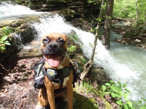

Since my students keep finding these photos of me on the dark web, I’m putting them here to get it out of the way and steal their sense of victory.

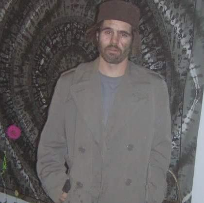

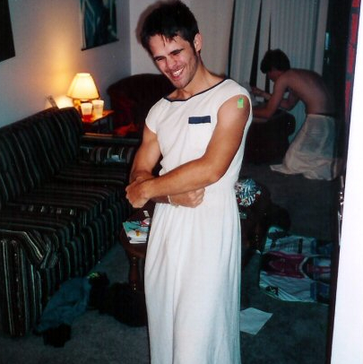

## Contact Info:

Geoffrey Zahn  
Biology Department - Utah Valley University  
800 W University Parkway - SB243c  
Orem, UT 84058  
zahn.geoff (at) gmail dot com